# Imaging Time Lags

Theresa Swayne

2/28/2020

## 3-channel STORM experiment

A 3-channel STORM expt was run with exposure time “1 frame” for 30000 frames. The time lag between successive frames was calculated from the metadata.

```r
mydir <- "~/Desktop/"
storm3ch <- read_excel(file.path(mydir,"2020-02-29 green timing/storm001.xlsx"))
storm3ch <- storm3ch[-c(1),c(1:11)] # remove blank row
storm3ch$TimeLag <- c(NA, diff(storm3ch$`Time [s]`)) # calculate time difference from one row to the next
```

The values have a wide range.

```r
summarise(storm3ch,mean=mean(TimeLag, na.rm = TRUE), stdev = sd(TimeLag, na.rm=TRUE), median = median(TimeLag, na.rm = TRUE), min=min(TimeLag,na.rm = TRUE), max=max(TimeLag,na.rm = TRUE))
```

```
## # A tibble: 1 x 5
##     mean  stdev median    min   max
##    <dbl>  <dbl>  <dbl>  <dbl> <dbl>
## 1 0.0644 0.0157 0.0632 0.0631 0.949
```

Most time intervals are short:

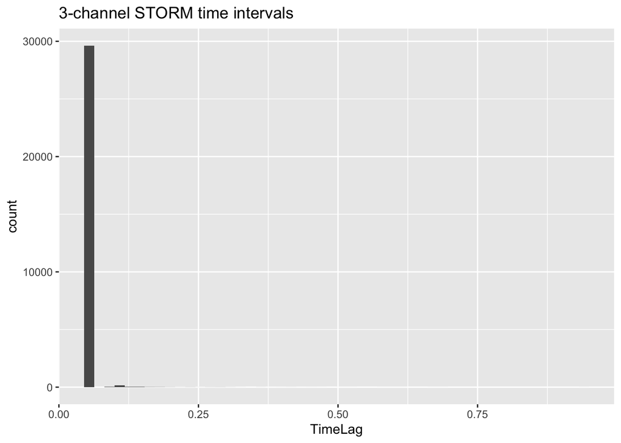

But there are a large number of timepoints where there is a longer lag between points:

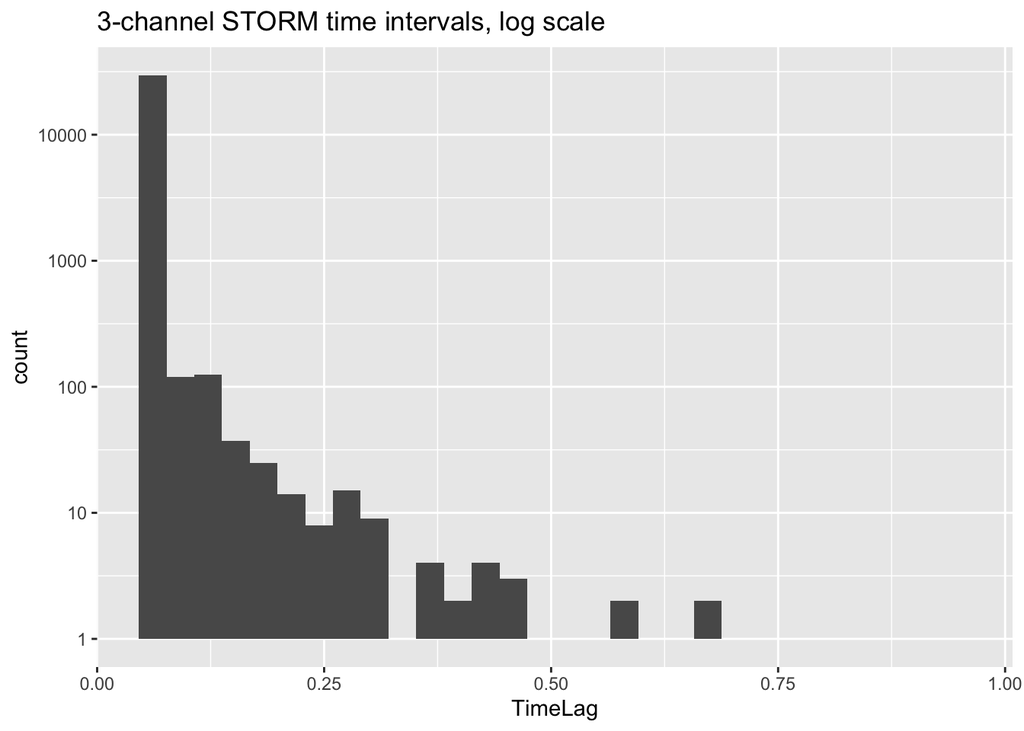

And these occur throughout the experiment:

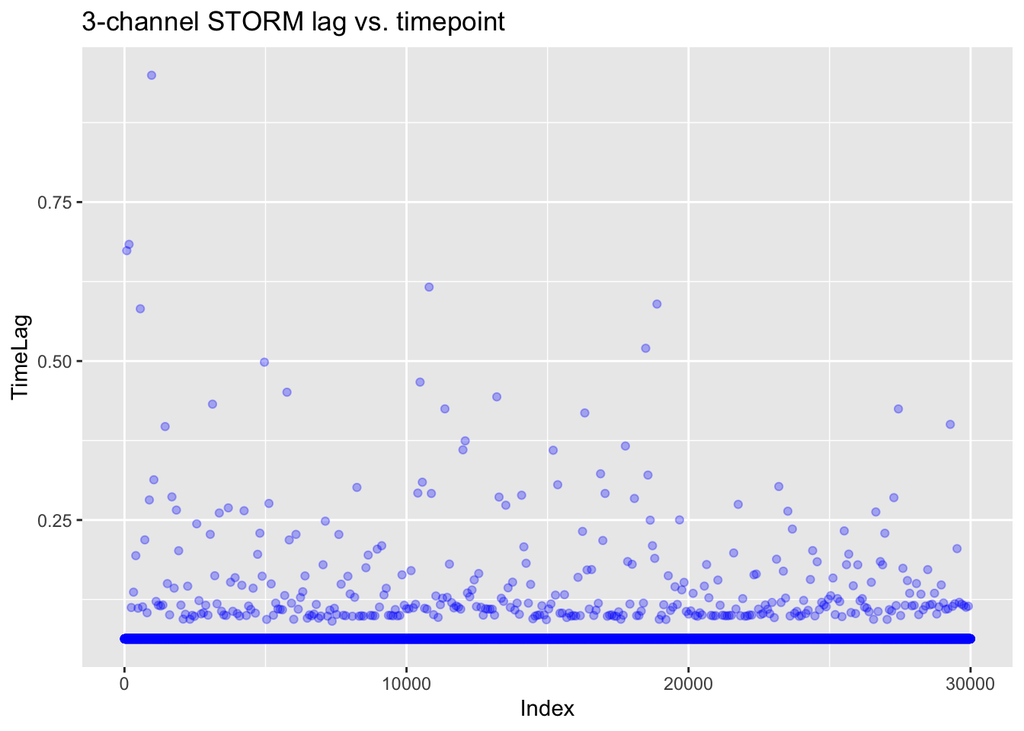

However, this lag added only slightly to the length of the experiment:

```r
expected <- median(storm3ch$TimeLag, na.rm=TRUE) * length(storm3ch$TimeLag)
paste("Median time * # timepoints =",expected, "s expected time required")
```

```
## [1] "Median time * # timepoints = 1895.99999999984 s expected time required"
```

```r
actual <- sum(storm3ch$TimeLag, na.rm=TRUE)
paste("Sum of time intervals =", actual, "s actual time taken")
```

```
## [1] "Sum of time intervals = 1930.6429 s actual time taken"
```

```r
delay <- (actual - expected)/60
paste("Actual time - expected time =",delay,"min added in 30-min experiment")
```

```
## [1] "Actual time - expected time = 0.57738166666926 min added in 30-min experiment"
```

## 1-channel STORM experiment

A 1-channel (647 nm) STORM experiment was run with all other parameters the same.

```r
storm1ch <- read_excel(file.path(mydir,"2020-02-29 green timing/storm 647 only.xlsx"))
storm1ch <- storm1ch[-c(1),c(1:11)] # remove blank row
storm1ch$TimeLag <- c(NA, diff(storm1ch$`Time [s]`)) # calculate time difference from one row to the next
```

Based on the histogram and the distribution throughout the experiment, the elimination of channels does not affect the lagging behavior.

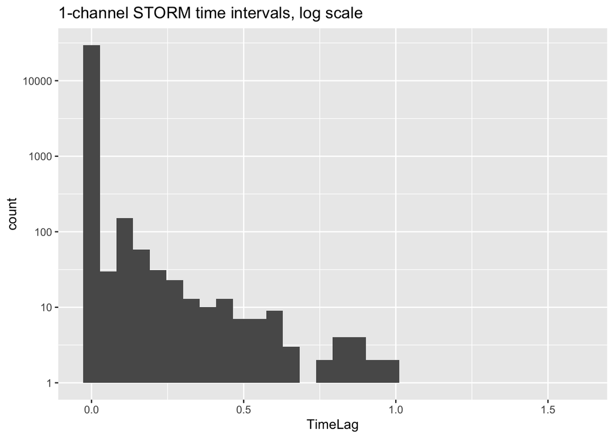

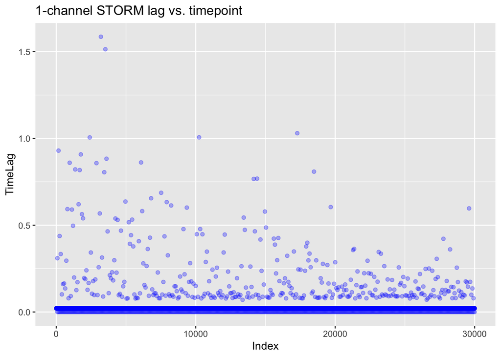

Although the mean interval is lower as expected, the standard deviation is higher.

```r
summarise(storm1ch,mean=mean(TimeLag, na.rm = TRUE), stdev = sd(TimeLag, na.rm=TRUE), median = median(TimeLag, na.rm = TRUE), min=min(TimeLag,na.rm = TRUE), max=max(TimeLag,na.rm = TRUE))
```

```
## # A tibble: 1 x 5
##     mean  stdev median   min   max
##    <dbl>  <dbl>  <dbl> <dbl> <dbl>
## 1 0.0234 0.0334 0.0211     0  1.59
```

```r
expected1ch <- median(storm1ch$TimeLag, na.rm=TRUE) * length(storm1ch$TimeLag)
paste("Median time * # timepoints =",expected1ch, "s expected time required")
```

```
## [1] "Median time * # timepoints = 632.999999997992 s expected time required"
```

```r
actual1ch <- sum(storm1ch$TimeLag, na.rm=TRUE)
paste("Sum of time intervals =", actual1ch, "s actual time taken")
```

```
## [1] "Sum of time intervals = 701.3249 s actual time taken"
```

```r
delay1ch <- (actual1ch - expected1ch)/60
paste("Actual time - expected time =",delay1ch,"min added in 30-min 1-channel experiment")
```

```
## [1] "Actual time - expected time = 1.1387483333668 min added in 30-min 1-channel experiment"
```

## Andor EMCCD without STORM

A triggered TIRF experiment was run with all imaging parameters the same but only 1000 frames.

```r
trigtirf <- read_excel(file.path(mydir,"2020-02-29 green timing/triggered tirf.xlsx"))
trigtirf  <- trigtirf[-c(1),c(1:11)] # remove blank row
trigtirf$TimeLag <- c(NA, diff(trigtirf$`Time [s]`)) # calculate time difference from one row to the next
```

Here, the time intervals were much more consistent.

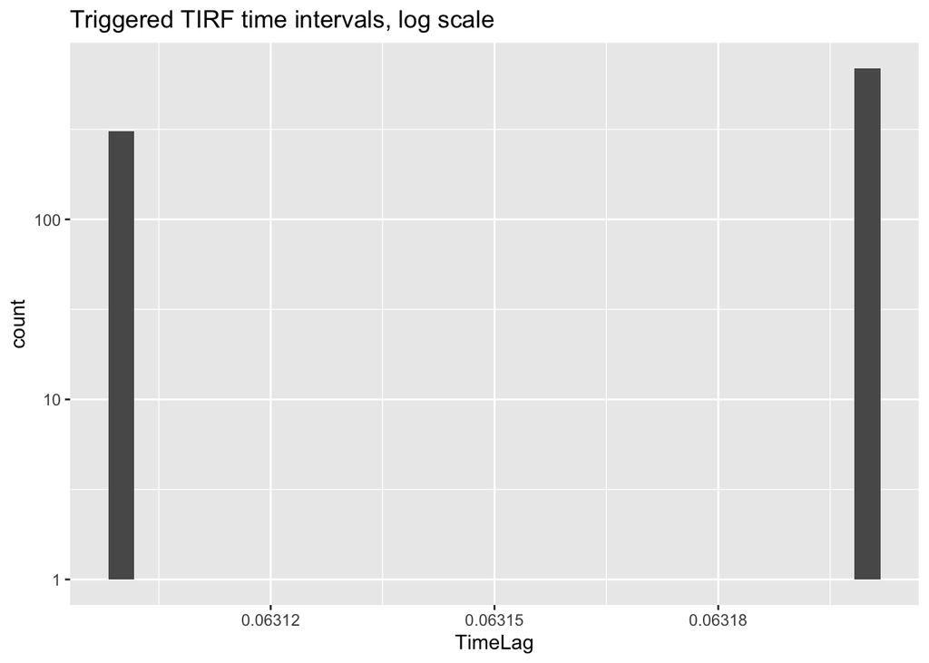

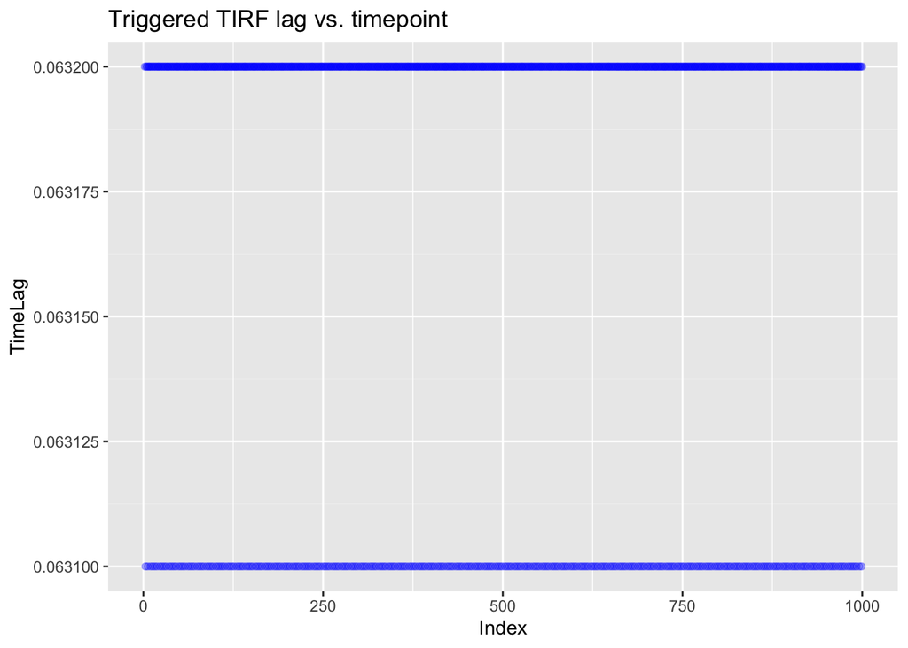

In a straight TIRF experiment, as expected from the graphs, the delay is negligible.

```r
summarise(trigtirf,mean=mean(TimeLag, na.rm = TRUE), stdev = sd(TimeLag, na.rm=TRUE), median = median(TimeLag, na.rm = TRUE), min=min(TimeLag,na.rm = TRUE), max=max(TimeLag,na.rm = TRUE))
```

```
## # A tibble: 1 x 5
##     mean     stdev median    min    max
##    <dbl>     <dbl>  <dbl>  <dbl>  <dbl>
## 1 0.0632 0.0000462 0.0632 0.0631 0.0632
```

```r
expected_trigtirf <- median(trigtirf$TimeLag, na.rm=TRUE) * length(trigtirf$TimeLag)
paste("Median time * # timepoints =",expected_trigtirf, "s expected time required")
```

```
## [1] "Median time * # timepoints = 63.1999999999984 s expected time required"
```

```r
actual_trigtirf <- sum(trigtirf$TimeLag, na.rm=TRUE)
paste("Sum of time intervals =", actual_trigtirf, "s actual time taken")
```

```
## [1] "Sum of time intervals = 63.106 s actual time taken"
```

```r
delay_trigtirf <- (actual_trigtirf - expected_trigtirf)/60
paste("Actual time - expected time =",delay_trigtirf,"min added in 1000-frame experiment")
```

```
## [1] "Actual time - expected time = -0.00156666666663945 min added in 1000-frame experiment"
```

## 4-channel triggered spinning-disk experiments

A triggered spinning-disk experiment was run with 1-frame exposure and 4 channels, 680 frames.

Here we also had extremely low variability.

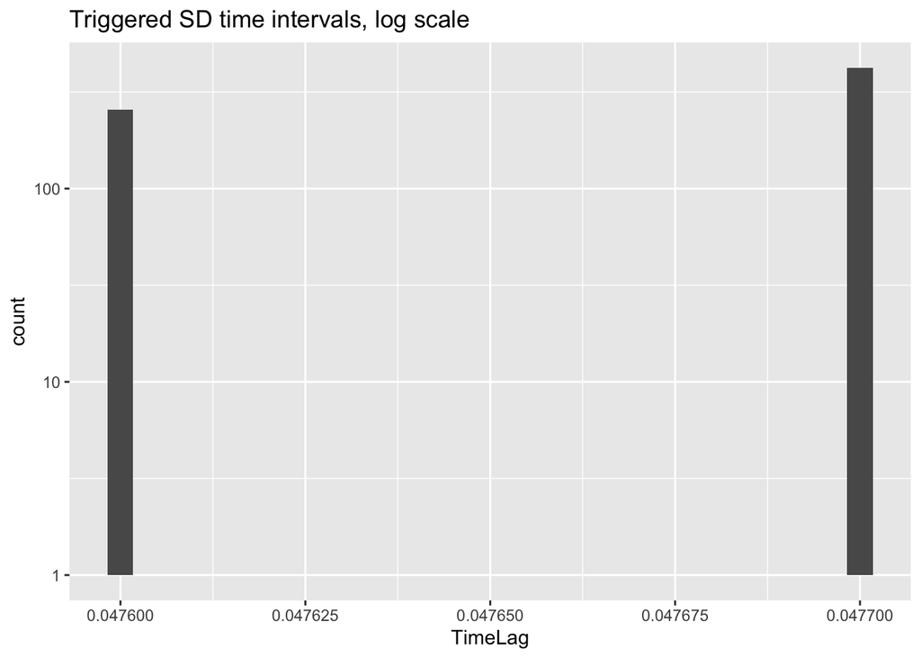

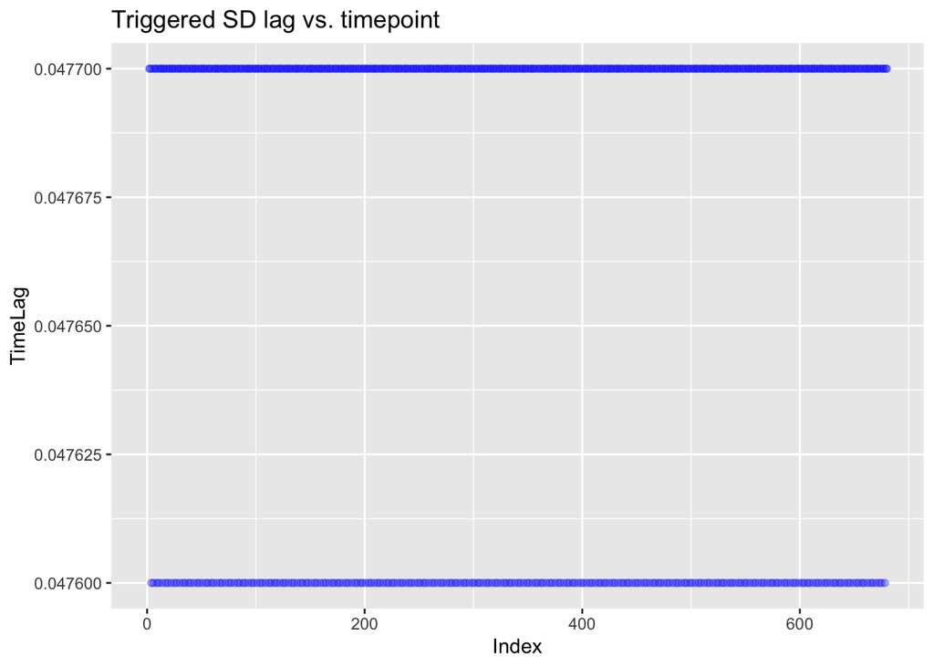

```
## # A tibble: 1 x 5
##     mean     stdev median    min    max
##    <dbl>     <dbl>  <dbl>  <dbl>  <dbl>
## 1 0.0477 0.0000485 0.0477 0.0476 0.0477
```

```
## [1] "Median time * # timepoints = 32.4359999999993 s expected time required"
```

```
## [1] "Sum of time intervals = 32.3626 s actual time taken"
```

```
## [1] "Actual time - expected time = -0.0012233333333216 min added in 680-frame experiment"
```

Another triggered spinning-disk experiment was run with 1-frame exposure and 4 channels, with 128x128 ROI, for 2000 frames. Results are similar.

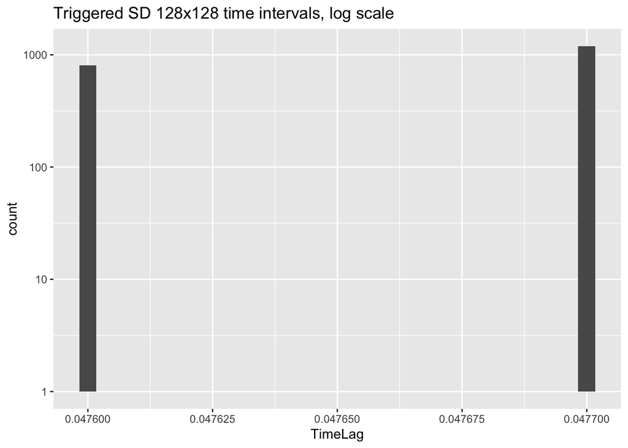

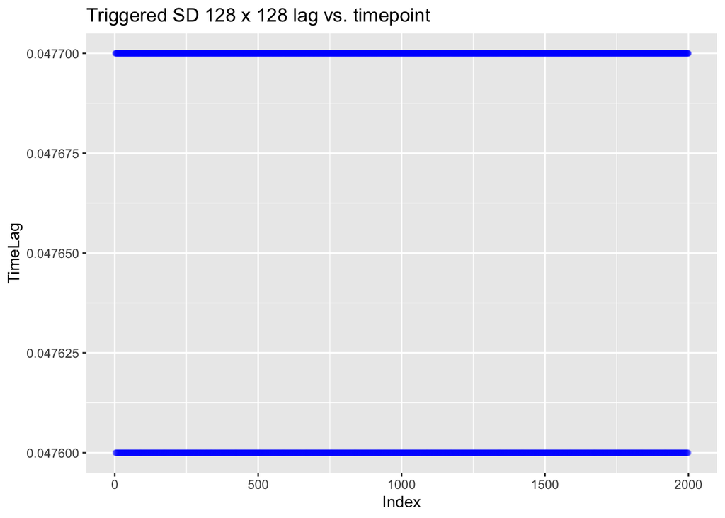

```
## # A tibble: 1 x 5
##     mean     stdev median    min    max
##    <dbl>     <dbl>  <dbl>  <dbl>  <dbl>
## 1 0.0477 0.0000490 0.0477 0.0476 0.0477
```

```
## [1] "Median time * # timepoints = 95.3999999999979 s expected time required"
```

```
## [1] "Sum of time intervals = 95.2719 s actual time taken"
```

```
## [1] "Actual time - expected time = -0.00213499999996548 min added in 2000-frame experiment"
```